# PADP_8120_Lab7: T-tests

Tyler Scott

2015-08-15

# Lab Topics

- t-tests

Special topic:

-data in the wild (again) for t-tests

## Goals:

After this lab you will be able to:

- Conduct 1, 2, and paired-sample t-test in R
- This lab uses materials by Mine Cetinkaya-Rundel

# One and Two-sample t-tests

The R function t.test() can be used to perform both one and two sample t-tests on vectors of data. The function contains a variety of options and can be called as follows:

```r
t.test(x, y = NULL, alternative = c("two.sided", "less", "greater"), mu = 0, paired =
FALSE, var.equal = FALSE, conf.level = 0.95)
```

Here `x` is a numeric vector of data values and `y` is an optional numeric vector of data values. If `y` is excluded, the function performs a one-sample t-test on the data contained in `x`, if it is included it performs a two-sample t-tests using both `x` and `y`. The option `mu` provides a number indicating the true value of the mean (or difference in means if you are performing a two sample test) under the null hypothesis. The option alternative is a character string specifying the alternative hypothesis, and must be one of the following: “two.sided” (which is the default), “greater” or “less” depending on whether the alternative hypothesis is that the mean is different than, greater than or less than mu, respectively. For example the following call:

```r
t.test(x, alternative = "less", mu = 10)
```

performs a one sample t-test on the data contained in x where the null hypothesis is that =10 and the alternative is that <10. The option paired indicates whether or not you want a paired t-test (TRUE = yes and FALSE = no). If you leave this option out it defaults to FALSE. The option var.equal is a logical variable indicating whether or not to assume the two variances as being equal when performing a two-sample t-test. If TRUE then the pooled variance is used to estimate the variance otherwise the Welch (or Satterthwaite) approximation to the degrees of freedom is used. If you leave this option out it defaults to FALSE.

Finally, the option conf.level determines the confidence level of the reported confidence interval for in the one-sample case and 1- 2 in the two-sample case.

## One-sample t-tests

For example, an outbreak of Salmonella-related illness was attributed to ice cream produced at a certain factory. Scientists measured the level of Salmonella in 9 randomly sampled batches of ice cream. The levels (in MPN/g) were:

```r
salmonella = c(0.593, 0.142, 0.329, 0.691, 0.231, 0.793, 0.519, 0.392, 0.418)
```

Is there evidence that the mean level of Salmonella in the ice cream is greater than 0.3 MPN/g? Let $\mu$ be the mean level of Salmonella in all batches of ice cream. Here the hypothesis of interest can be expressed as:

$H_{0}: \mu = 0.3$ $H_{A}: \mu > 0.3$

Hence, we will need to include the options alternative=“greater”, mu=0.3. Below is the relevant R-code:

```r
t.test(salmonella, alternative="greater", mu=0.3)
```

You should get output that shows a p-value of 0.029:

```r
t.test(salmonella, alternative="greater", mu=0.3)
```

```
##
##  One Sample t-test
##
## data:  salmonella
## t = 2.2051, df = 8, p-value = 0.02927
## alternative hypothesis: true mean is greater than 0.3
## 95 percent confidence interval:
##  0.3245133       Inf
## sample estimates:
## mean of x
## 0.4564444
```

Hence, there is moderately strong evidence that the mean Salmonella level in the ice cream is above 0.3 MPN/g.

We can duplicate this result **without** using the `t.test` function using the `pt/qt/dt` family:

```r
#t.obs = (obs - expected) / SD
t.obs = (mean(salmonella) - 0.3) / {sd(salmonella) / sqrt(length(salmonella))}
1 - pt(t.obs,df = length(salmonella)-1)
```

This is actually how you might prefer to compute these types of tests, because the output is easier to deal with if you are in turn feeding this value into another function or table.

## Two-sample t-tests

6 subjects were given a drug (treatment group) and an additional 6 subjects a placebo (control group). Their reaction time to a stimulus was measured (in ms). We want to perform a two-sample t-test for comparing the means of the treatment and control groups.

Let $\mu_1$ be the mean of the population taking medicine and $\mu_2$ the mean of the untreated population. Here the hypothesis of interest can be expressed as:

$H_{0}: \mu_1 - \mu_2 = 0$ $H_{A}: \mu_1 - \mu_2 != 0$

Here we will need to include the data for the treatment group in x and the data for the control group in y. We will also need to include the options alternative=“two.sided”, $\mu=0$. Finally, we need to decide whether or not the standard deviations are the same in both groups (in a case like this where we only have six observation in each group, this really comes down to a judgment call…). Below is the relevant R-code when assuming equal standard deviation:

```r
Control = c(91, 87, 99, 77, 88, 91)
Treat = c(101, 110, 103, 93, 99, 104)
t.test(Control,Treat,alternative="two.sided", var.equal=TRUE)
```

Below is the relevant R-code when not assuming equal standard deviation:

```r
t.test(Control,Treat,alternative="two.sided")
```

Note that when we **do not** assume equal variance, the function performs a Welch test instead of the standard two-sample t-test we learned in lecture. Welch’s test is more reliable when the two groups: (a) have very different sample sizes; and/or (b) have unequal variances. The basic difference is that the Student’s t-test computes a pooled standard deviation, whereas the Welch test uses an unpooled variance. We actually used the Welch’s t-test in lecture:

$t_{diff} = \frac{estimate - null}{\sqrt{\frac{s^{2}_{1}}{n_{1}} + \frac{s^{2}_{2}}{n_{2}}}}$

```r
#t.obs = (obs - expected) / SD
t.obs = ((mean(Control)-mean(Treat)) - 0) / sqrt({sd(Control)^2 / length(Control)} + {sd(Treat)^2 / length(Treat)})
2 * pt(t.obs,df = min(length(Control),length(Treat))-1)
```

```
## [1] 0.0183241
```

Why do we need to multiply this result by 2? Recall that we are conducting a two-sided test, but `pt` only gives us the probability associated with one tail or another. Thus, we have to double the output to find the probability associated with each tail. The `t.obs` should match perfectly with the `t.test` output, but the `pt` result will be slightly different due to the shortcut we took with inputing the degrees of freedom (we used df = 5 instead of the approximation 9.4797).

1. Try re-running the `pt` code above, but plug in the Welch-Satterthwaite df approximation you get as part of the `t.test` output. Do the p-values you get from the `pt` method and the `t.test` method match up now?

```r
2 * pt(t.obs,df = t.test(Control,Treat,alternative="two.sided")$parameter)
```

```
## [1] 0.00678246
```

The p-values are basically identical now. The `parameter` value is the df statistic shown when you run the `t.test` comman.

# Paired t-tests

There are many experimental settings where each subject in the study is in both the treatment and control group. For example, in a matched pairs design, subjects are matched in pairs and different treatments are given to each subject in the pair. The outcomes are thereafter compared pair-wise. Alternatively, one can measure each subject twice, before and after a treatment. In either of these situations we can’t use two-sample t-tests since the independence assumption is not valid. Instead we need to use a paired t-test. This can be done using the option paired =TRUE.

For example, a study was performed to test whether cars get different mileage on premium gas than on regular gas. Each of 10 cars was first filled with either regular or premium gas, decided by a coin toss, and the mileage for that tank was recorded. The mileage was recorded again for the same cars using the other kind of gasoline. We use a paired t-test to determine whether cars get significantly different mileage with premium gas.

```r
reg = c(16, 20, 21, 22, 23, 22, 27, 25, 27, 28)
prem = c(19, 22, 24, 24, 25, 25, 26, 26, 28, 32)
t.test(prem,reg,alternative="two.sided", paired=TRUE)
```

Again, we can use `pt` to do this by hand (or kind-of by hand):

```r
t.obs = mean(reg - prem) / (sd(reg-prem)/sqrt(length(reg-prem)))
2*pt(t.obs,df=9)
```

# Your turn

## North Carolina births

In 2004, the state of North Carolina released a large data set containing information on births recorded in this state. This data set is useful to researchers studying the relation between habits and practices of expectant mothers and the birth of their children. We will work with a random sample of observations from this data set.

## Exploratory analysis

Load the `nc` data set into our workspace.

```r
download.file("http://www.openintro.org/stat/data/nc.RData", destfile = "nc.RData")
load("nc.RData")
```

We have observations on 13 different variables, some categorical and some numerical. The meaning of each variable is as follows.

| variable | description |
| --- | --- |
| `fage` | father’s age in years. |
| `mage` | mother’s age in years. |
| `mature` | maturity status of mother. |
| `weeks` | length of pregnancy in weeks. |
| `premie` | whether the birth was classified as premature (premie) or full-term. |
| `visits` | number of hospital visits during pregnancy. |
| `marital` | whether mother is `married` or `not married` at birth. |
| `gained` | weight gained by mother during pregnancy in pounds. |
| `weight` | weight of the baby at birth in pounds. |
| `lowbirthweight` | whether baby was classified as low birthweight (`low`) or not (`not low`). |
| `gender` | gender of the baby, `female` or `male`. |
| `habit` | status of the mother as a `nonsmoker` or a `smoker`. |
| `whitemom` | whether mom is `white` or `not white`. |

1. What are the cases in this data set? How many cases are there in our sample?

As a first step in the analysis, we should consider summaries of the data. This can be done using the `summary` command:

```r
summary(nc)
```

```
##       fage            mage            mature        weeks
##  Min.   :14.00   Min.   :13   mature mom :133   Min.   :20.00
##  1st Qu.:25.00   1st Qu.:22   younger mom:867   1st Qu.:37.00
##  Median :30.00   Median :27                     Median :39.00
##  Mean   :30.26   Mean   :27                     Mean   :38.33
##  3rd Qu.:35.00   3rd Qu.:32                     3rd Qu.:40.00
##  Max.   :55.00   Max.   :50                     Max.   :45.00
##  NA's   :171                                    NA's   :2
##        premie        visits            marital        gained
##  full term:846   Min.   : 0.0   married    :386   Min.   : 0.00
##  premie   :152   1st Qu.:10.0   not married:613   1st Qu.:20.00
##  NA's     :  2   Median :12.0   NA's       :  1   Median :30.00
##                  Mean   :12.1                     Mean   :30.33
##                  3rd Qu.:15.0                     3rd Qu.:38.00
##                  Max.   :30.0                     Max.   :85.00
##                  NA's   :9                        NA's   :27
##      weight       lowbirthweight    gender          habit
##  Min.   : 1.000   low    :111    female:503   nonsmoker:873
##  1st Qu.: 6.380   not low:889    male  :497   smoker   :126
##  Median : 7.310                               NA's     :  1
##  Mean   : 7.101
##  3rd Qu.: 8.060
##  Max.   :11.750
##
##       whitemom
##  not white:284
##  white    :714
##  NA's     :  2
##
##
##
##
```

As you review the variable summaries, consider which variables are categorical and which are numerical. For numerical variables, are there outliers? If you aren’t sure or want to take a closer look at the data, make a graph.

Consider the possible relationship between a mother’s smoking habit and the weight of her baby. Plotting the data is a useful first step because it helps us quickly visualize trends, identify strong associations, and develop research questions.

2. Make a side-by-side boxplot of `habit` and `weight`. What does the plot highlight about the relationship between these two variables?

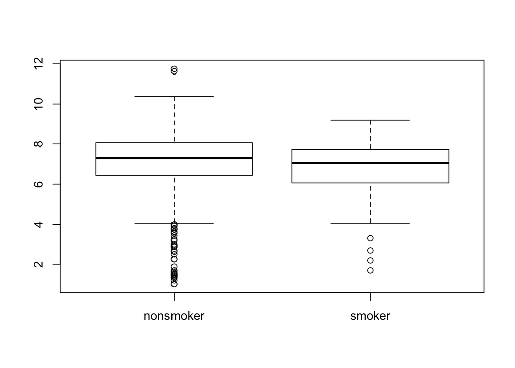

```r
boxplot(nc$weight~nc$habit)
```

It looks like nonsmoking mothers typically have higher-birthweight babies, although the difference is not huge. It looks like the primary difference is on the upper end - only nonsmoking mothers seem to have babies above 10 pounds.

The box plots show how the medians of the two distributions compare, but we can also compare the means of the distributions using the following function to split the `weight` variable into the `habit` groups, then take the mean of each using the `mean` function.

```r
by(nc$weight, nc$habit, mean)
```

```
## nc$habit: nonsmoker
## [1] 7.144273
## --------------------------------------------------------
## nc$habit: smoker
## [1] 6.82873
```

3. Recall the `apply` family of functions: repeat the operation above, but use the `tapply` function

```r
tapply(nc$weight,nc$habit,mean)
```

```
## nonsmoker    smoker
##  7.144273  6.828730
```

There is an observed difference, but is this difference statistically significant (i.e., is it more likely that the two “True” values are identical but we observed a difference due to random chance, or is it more likely that the two values really are different?)? In order to answer this question we will conduct a hypothesis test.

## Inference

4. Check if the conditions necessary for inference are satisfied (independence within groups, independence between groups, sample sizes both above 30, and symmetric distributions). Note that you will need to obtain sample sizes to check the conditions. You can compute the group size using the same `by` command above but replacing `mean` with `length`. You can also accomplish the same thing using the `table()` function:

```r
table(nc$habit)
```

```
##
## nonsmoker    smoker
##       873       126
```

- The table function results show that both groups have n >30.
- Independence is an assumption, but it seems founded in case; the weight of one baby should not affect the weight of any other, and likewise baby weights within either group should have no bearing on the other group.
- The boxplot above gives us an indication that each distribution is close to symmetric, but perhaps skewed to the left. This makes sense, since babies born early can weigh very, very little, but there’s basically no such thing as a baby that weights more than about 12 pounds. Let’s check:

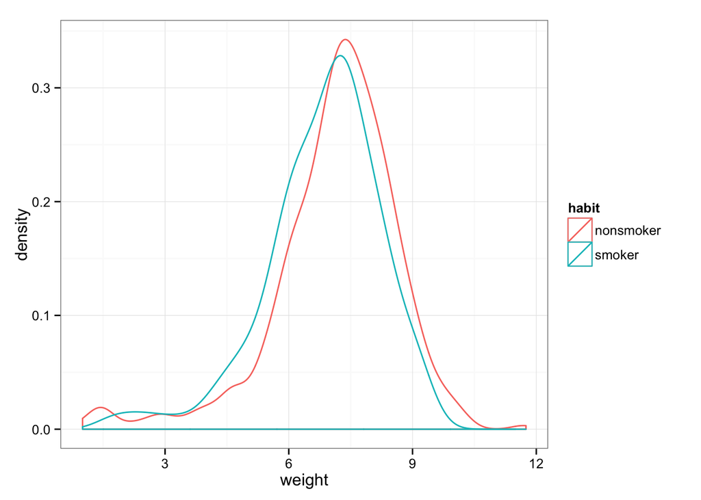

```r
library(ggplot2)
ggplot(nc,aes(x=weight,group=habit,col=habit)) + geom_density() + theme_bw()
```

As the plot shows, both distributions are *roughly* symmetric, at least good enought to proceed.

5 Write the hypotheses for testing if the average weights of babies born to smoking and non-smoking mothers are different.

H0: There is no difference in average birth weight between babies born to smoking and non-smoking mothers

HA: The average birth weight of babies born to smoking mothers is different than the average weight of babies born to non-smoking numbers.

6. Test this hypothesis using the `t.test` function.

```r
t.test(nc$weight[nc$habit=='nonsmoker'],nc$weight[nc$habit=='smoker'])
```

```
##
##  Welch Two Sample t-test
##
## data:  nc$weight[nc$habit == "nonsmoker"] and nc$weight[nc$habit == "smoker"]
## t = 2.359, df = 171.32, p-value = 0.01945
## alternative hypothesis: true difference in means is not equal to 0
## 95 percent confidence interval:
##  0.05151165 0.57957328
## sample estimates:
## mean of x mean of y
##  7.144273  6.828730
```

Since p < 0.05 (or since $t_{obs} > t_{\alpha/2,df=171.32}$), we reject the null hypothesis and conclude that there is good evidence to support that there is a significant different in birth weight between babies born to nonsmoking and smoking mothers.

7. Find the 99% confidence interval for the difference of sample means (hint: look at the `conf.level` setting within the `t.test` function)

The easiest way to do this is to reset the significance level:

```r
t.test(nc$weight[nc$habit=='nonsmoker'],nc$weight[nc$habit=='smoker'],conf.level=0.99)
```

```
##
##  Welch Two Sample t-test
##
## data:  nc$weight[nc$habit == "nonsmoker"] and nc$weight[nc$habit == "smoker"]
## t = 2.359, df = 171.32, p-value = 0.01945
## alternative hypothesis: true difference in means is not equal to 0
## 99 percent confidence interval:
##  -0.03288088  0.66396580
## sample estimates:
## mean of x mean of y
##  7.144273  6.828730
```

and we find that the 99% confidence interval for the average difference is -0.03 to 0.66.

8. Duplicate the test in item 5 using the `pt` function.

```r
t.obs = ((mean(nc$weight[nc$habit=='nonsmoker'],na.rm=T)-
            mean(nc$weight[nc$habit=='smoker'],na.rm=T)) - 0) / sqrt({sd(nc$weight[nc$habit=='nonsmoker'],na.rm=T)^2 / length(nc$weight[nc$habit=='nonsmoker'])} + {sd(nc$weight[nc$habit=='smoker'],na.rm=T)^2 / length(nc$weight[nc$habit=='smoker'])})

(2 * pt(t.obs,df = min(length(nc$weight[nc$habit=='smoker']),length(nc$weight[nc$habit=='nonsmoker']))-1))
```

```
## [1] 1.980553
```

9. Calculate a 95% confidence interval for the average length of pregnancies (`weeks`) and interpret it in context.

```r
avg.wk <- mean(nc$weeks,na.rm=T)
sd.wk <- sd(nc$weeks,na.rm=T)
n.wk <- length(nc$weeks[!is.na(nc$weeks)])
t.crit <- qt(p = c(0.025,0.975),df = n.wk-1)
avg.wk + t.crit * (sd.wk/sqrt(n.wk))
```

```
## [1] 38.15257 38.51677
```

We are 95% confident that the true average pregnancy length is between 38.15 and 38.52 weeks.

10. Calculate a new confidence interval for the same parameter at the 90% confidence level.

```r
t.crit <- qt(p = c(0.05,0.95),df = n.wk-1)
avg.wk + t.crit * (sd.wk/sqrt(n.wk))
```

```
## [1] 38.18189 38.48745
```

We are 90% confident that the true average pregnancy length is between 38.18 and 38.49 weeks.

11. Conduct a hypothesis test evaluating whether the average weight gained by younger mothers is different than the average weight gained by mature mothers.

H0: Young mothers and mature mothers gain the same amount of weight during pregnancy.

HA: Young mothers and mature mothers gain a different amount of weight during pregnancy.

```r
t.test(nc$gained[nc$mature=='mature mom'],nc$gained[nc$mature=='younger mom'])
```

```
##
##  Welch Two Sample t-test
##
## data:  nc$gained[nc$mature == "mature mom"] and nc$gained[nc$mature == "younger mom"]
## t = -1.3765, df = 175.34, p-value = 0.1704
## alternative hypothesis: true difference in means is not equal to 0
## 95 percent confidence interval:
##  -4.3071463  0.7676886
## sample estimates:
## mean of x mean of y
##  28.79070  30.56043
```

As p > 0.17, we fail to reject the null hypothesis (basically at any significance level) and conclude that there is no good evidence to support that young and mature mothers gain a differential amount of weight during pregnancy.

12. Pick a pair of numerical and categorical variables and come up with a research question evaluating the relationship between these variables. Formulate the question in a way that it can be answered using a hypothesis test and/or a confidence interval. Report the statistical results, and also provide an explanation in plain language.